# Trabajo Práctico N° 2: Análisis de cluster

Melina Schamberger

11/6/2022

# Análisis de cluster

## Tickets de supermercado

Los datos de los tickets de supermercado permiten construir clusters para formar segmentos de consumidores.

## Objetivos del análisis de cluster

- Segmentar los objetos (clientes) en grupos con perfiles similares
- Una vez identificados los segmentos, las empresas/supermercados pueden formular estrategias con diferentes atractivos para distintos grupos de consumidores.

### 0. Librerías

```r
library(tidyverse)
library(readxl)
library(ggthemes)
library(ggpubr)
library(kableExtra)
library(cluster)
library(factoextra)
```

### 1. Lectura de datos

```r
df <- read_excel("DATOS TICKETS SCENTIA.xlsx")
tabla_1 <- head(df)
kable_styling(kable(tabla_1))
```

| CANAL | Numero de Ticket | DiaSemana | TotalTicket$ | PrecioMaximo | PrecioMinimo | Cantidad_PRODUCTOS_DIFERENTES | CantidadUnidades | Categorias | PrecioPromedio | ALIMENTACION | BEBIDAS CON ALCOHOL | BEBIDAS SIN ALCOHOL | DESAYUNO Y MERIENDA | HIGIENE Y COSMETICA | IMPULSIVOS | LIMPIEZA DE ROPA Y HOGAR | PERECEDEROS |
| --- | --- | --- | --- | --- | --- | --- | --- | --- | --- | --- | --- | --- | --- | --- | --- | --- | --- |
| AUTO INDEPENDIENTE | 91715 | Domingo | 28 | 28 | 28 | 1 | 1 | 1 | 28.00000 | 0 | 0 | 0 | 1 | 0 | 0 | 0 | 0 |
| AUTO INDEPENDIENTE | 91716 | Domingo | 208 | 100 | 39 | 3 | 3 | 1 | 69.33333 | 0 | 1 | 0 | 0 | 0 | 0 | 0 | 0 |
| AUTO INDEPENDIENTE | 91719 | Domingo | 352 | 125 | 65 | 4 | 4 | 4 | 88.00000 | 0 | 0 | 0 | 2 | 0 | 0 | 2 | 0 |
| AUTO INDEPENDIENTE | 91720 | Domingo | 72 | 72 | 72 | 1 | 1 | 1 | 72.00000 | 0 | 1 | 0 | 0 | 0 | 0 | 0 | 0 |
| AUTO INDEPENDIENTE | 91721 | Domingo | 198 | 73 | 21 | 5 | 5 | 4 | 39.60000 | 3 | 0 | 0 | 1 | 0 | 0 | 0 | 0 |
| AUTO INDEPENDIENTE | 91722 | Domingo | 220 | 55 | 55 | 1 | 4 | 1 | 55.00000 | 0 | 1 | 0 | 0 | 0 | 0 | 0 | 0 |

Resumen de los datos.

```r
tabla_2 <- summary(df)
kable_styling(kable(tabla_2))
```

|  | CANAL | Numero de Ticket | DiaSemana | TotalTicket$ | PrecioMaximo | PrecioMinimo | Cantidad_PRODUCTOS_DIFERENTES | CantidadUnidades | Categorias | PrecioPromedio | ALIMENTACION | BEBIDAS CON ALCOHOL | BEBIDAS SIN ALCOHOL | DESAYUNO Y MERIENDA | HIGIENE Y COSMETICA | IMPULSIVOS | LIMPIEZA DE ROPA Y HOGAR | PERECEDEROS |
| --- | --- | --- | --- | --- | --- | --- | --- | --- | --- | --- | --- | --- | --- | --- | --- | --- | --- | --- |
|  | Length:162494 | Min. :1.050e+02 | Length:162494 | Min. :-1014.3 | Min. : 0.0 | Min. : 0.00 | Min. : 1.000 | Min. :-20.540 | Min. : 0.000 | Min. : 0.00 | Min. : 0.0000 | Min. :0.0000 | Min. :0.000 | Min. : 0.000 | Min. : 0.0000 | Min. :0.0000 | Min. : 0.0000 | Min. :0.0000 |
|  | Class :character | 1st Qu.:3.817e+05 | Class :character | 1st Qu.: 75.0 | 1st Qu.: 50.0 | 1st Qu.: 24.50 | 1st Qu.: 1.000 | 1st Qu.: 1.000 | 1st Qu.: 1.000 | 1st Qu.: 40.42 | 1st Qu.: 0.0000 | 1st Qu.:0.0000 | 1st Qu.:0.000 | 1st Qu.: 0.000 | 1st Qu.: 0.0000 | 1st Qu.:0.0000 | 1st Qu.: 0.0000 | 1st Qu.:0.0000 |
|  | Mode :character | Median :3.047e+09 | Mode :character | Median : 140.0 | Median : 75.0 | Median : 40.00 | Median : 2.000 | Median : 2.000 | Median : 2.000 | Median : 57.45 | Median : 0.0000 | Median :0.0000 | Median :0.000 | Median : 0.000 | Median : 0.0000 | Median :0.0000 | Median : 0.0000 | Median :0.0000 |
|  | NA | Mean :4.160e+09 | NA | Mean : 244.5 | Mean : 104.5 | Mean : 50.45 | Mean : 3.233 | Mean : 4.559 | Mean : 2.804 | Mean : 71.38 | Mean : 0.5335 | Mean :0.1766 | Mean :0.352 | Mean : 0.899 | Mean : 0.2207 | Mean :0.1822 | Mean : 0.1511 | Mean :0.1517 |
|  | NA | 3rd Qu.:8.300e+09 | NA | 3rd Qu.: 278.0 | 3rd Qu.: 112.0 | 3rd Qu.: 60.00 | 3rd Qu.: 4.000 | 3rd Qu.: 5.000 | 3rd Qu.: 3.000 | 3rd Qu.: 80.00 | 3rd Qu.: 1.0000 | 3rd Qu.:0.0000 | 3rd Qu.:1.000 | 3rd Qu.: 1.000 | 3rd Qu.: 0.0000 | 3rd Qu.:0.0000 | 3rd Qu.: 0.0000 | 3rd Qu.:0.0000 |
|  | NA | Max. :8.300e+09 | NA | Max. :11315.5 | Max. :77981.0 | Max. :77981.00 | Max. :118.000 | Max. :171.000 | Max. :59.000 | Max. :77981.00 | Max. :20.0000 | Max. :5.0000 | Max. :5.000 | Max. :17.000 | Max. :12.0000 | Max. :8.0000 | Max. :12.0000 | Max. :9.0000 |

El primer paso es identificar cualquier atipico de la muestra antes de empezar con las particiones.

Se observan valores mínimos negativos en el caso de TotalTicket$ y en CantidadUnidades.

Se analizan estos casos con mayor detalle y se observa que son muy pocos:

```r
negativos <- df %>% filter(`TotalTicket$` <0) %>% head()
tabla_3 <- negativos
kable_styling(kable(tabla_3))
```

| CANAL | Numero de Ticket | DiaSemana | TotalTicket$ | PrecioMaximo | PrecioMinimo | Cantidad_PRODUCTOS_DIFERENTES | CantidadUnidades | Categorias | PrecioPromedio | ALIMENTACION | BEBIDAS CON ALCOHOL | BEBIDAS SIN ALCOHOL | DESAYUNO Y MERIENDA | HIGIENE Y COSMETICA | IMPULSIVOS | LIMPIEZA DE ROPA Y HOGAR | PERECEDEROS |
| --- | --- | --- | --- | --- | --- | --- | --- | --- | --- | --- | --- | --- | --- | --- | --- | --- | --- |
| AUTO INDEPENDIENTE | 8300142477 | Viernes | -115.0 | 165 | 20 | 5 | 1 | 5 | 106.4286 | 0 | 1 | 1 | 0 | 1 | 0 | 2 | 0 |
| CADENA | 3037570845 | Martes | -108.0 | 108 | 108 | 1 | -1 | 1 | 108.0000 | 0 | 0 | 0 | 0 | 1 | 0 | 0 | 0 |
| CADENA | 3037570847 | Martes | -86.0 | 86 | 86 | 1 | -1 | 1 | 86.0000 | 0 | 0 | 0 | 1 | 0 | 0 | 0 | 0 |
| CADENA | 3037570923 | Martes | -52.0 | 52 | 52 | 1 | -1 | 1 | 52.0000 | 0 | 0 | 0 | 1 | 0 | 0 | 0 | 0 |
| CADENA | 3037571002 | Martes | -26.4 | 0 | 0 | 1 | 0 | 1 | 0.0000 | 0 | 0 | 0 | 1 | 0 | 0 | 0 | 0 |
| CADENA | 3038810632 | Jueves | -76.0 | 76 | 76 | 1 | -1 | 1 | 76.0000 | 0 | 0 | 1 | 0 | 0 | 0 | 0 | 0 |

También se exploran aquellos casos donde los valores de compra son muy altos:

```r
df_alto <- df %>% filter(PrecioMinimo > 20000)
tabla_4 <- head(df_alto)
kable_styling(kable(tabla_4))
```

| CANAL | Numero de Ticket | DiaSemana | TotalTicket$ | PrecioMaximo | PrecioMinimo | Cantidad_PRODUCTOS_DIFERENTES | CantidadUnidades | Categorias | PrecioPromedio | ALIMENTACION | BEBIDAS CON ALCOHOL | BEBIDAS SIN ALCOHOL | DESAYUNO Y MERIENDA | HIGIENE Y COSMETICA | IMPULSIVOS | LIMPIEZA DE ROPA Y HOGAR | PERECEDEROS |
| --- | --- | --- | --- | --- | --- | --- | --- | --- | --- | --- | --- | --- | --- | --- | --- | --- | --- |
| AUTO INDEPENDIENTE | 8300028021 | Lunes | 0 | 77909 | 77909 | 1 | 0 | 1 | 77909 | 0 | 0 | 0 | 1 | 0 | 0 | 0 | 0 |
| AUTO INDEPENDIENTE | 8300028356 | Martes | 0 | 77910 | 77910 | 1 | 0 | 1 | 77910 | 0 | 0 | 1 | 0 | 0 | 0 | 0 | 0 |
| AUTO INDEPENDIENTE | 8300035976 | Martes | 0 | 77918 | 77918 | 1 | 0 | 1 | 77918 | 0 | 0 | 0 | 1 | 0 | 0 | 0 | 0 |
| AUTO INDEPENDIENTE | 8300036969 | Jueves | 0 | 77981 | 77981 | 1 | 0 | 1 | 77981 | 0 | 1 | 0 | 0 | 0 | 0 | 0 | 0 |

### Análisis de variables

#### Días de la semana

Se analiza la distribución de compras en función del día de la semana

```r
dias <- df %>% group_by(DiaSemana) %>% summarise(total = n())
tabla_6 <- dias
kable_styling(kable(tabla_6))
```

| DiaSemana | total |
| --- | --- |
| Domingo | 18430 |
| Jueves | 23408 |
| Lunes | 26815 |
| Martes | 22622 |
| Miércoles | 22738 |
| Sábado | 23408 |
| Viernes | 25073 |

Se grafica la distribución relativa de compras por día de la semana:

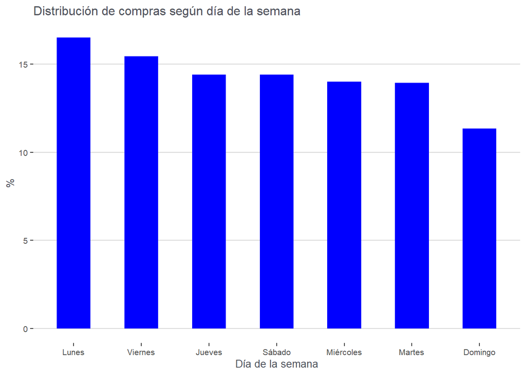

```r
dias_dos <- dias %>% mutate(can = 162494,
                            fre_re = (total/can)*100) %>% arrange(-fre_re)

dias_dos$fre_re <- round(dias_dos$fre_re, 3)

ggplot(data=dias_dos,
       aes(x=reorder(DiaSemana,-fre_re), y=fre_re)) +
        geom_bar(stat="identity", width = 0.5, fill = 'blue') +
        ggtitle ("Distribución de compras según día de la semana")+
              xlab("Día de la semana") +
              ylab("%") +
              theme_hc() +
              theme(legend.position = "null",
              text=element_text(size=10,
                                colour = "#50535C"))
```

#### Canal de compras

Se evalúa esta distribución según el canal de compra, teniendo en cuenta que el Lunes es el día con mayor compras y el Domingo el que registra la menor cantidad.

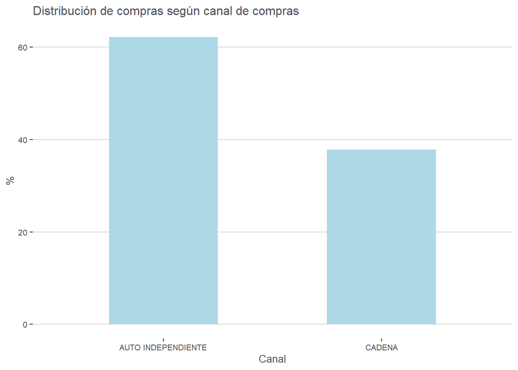

```r
canal <- df %>% group_by(CANAL) %>% summarise(total = n())
canal <- canal %>% mutate(can = 162494,
                          fre_re = (total/can)*100)

canal$fre_re <- round(canal$fre_re, 3)

ggplot(data=canal,
       aes(x=CANAL, y=fre_re)) +
        geom_bar(stat="identity", width = 0.5, fill = 'lightblue') +
        ggtitle ("Distribución de compras según canal de compras")+
              xlab("Canal") +
              ylab("%") +
              theme_hc() +
              theme(legend.position = "null",
              text=element_text(size=10,
                                colour = "#50535C"))
```

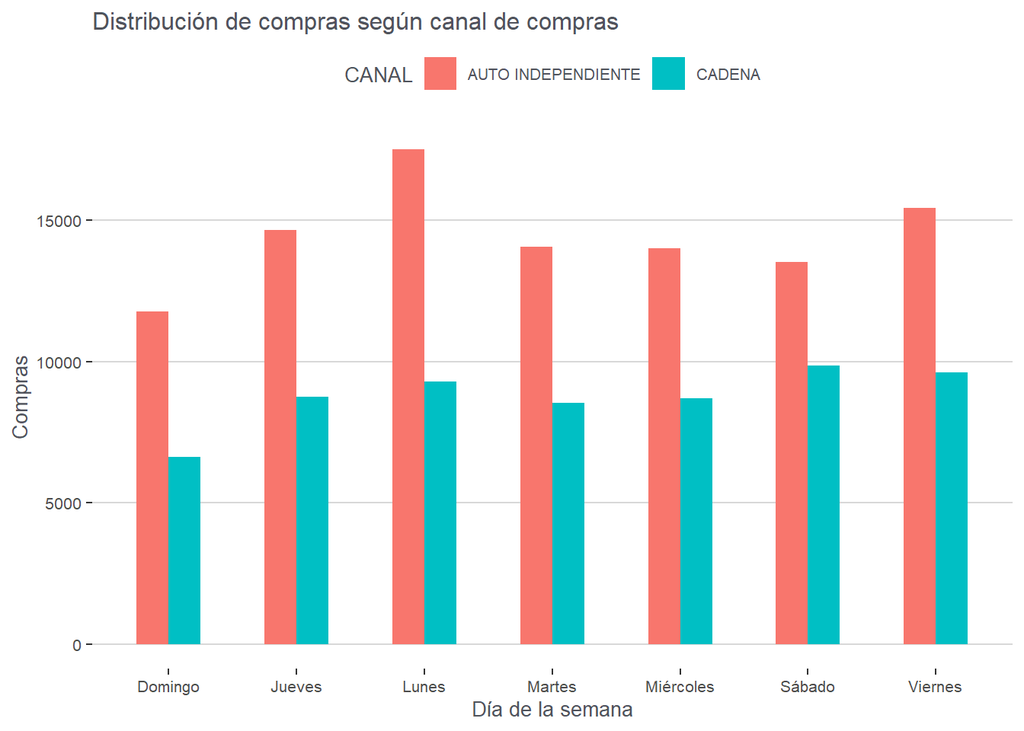

```r
canal <- df %>% group_by(CANAL, DiaSemana) %>% summarise(total = n())

ggplot(data=canal,
       aes(x=DiaSemana, y=total, fill= CANAL)) +
        geom_bar( stat="identity", position=position_dodge(),width = 0.5) +
        ggtitle ("Distribución de compras según canal de compras")+
              xlab("Día de la semana") +
              ylab("Compras") +
              theme_hc() +
              theme(legend.position = "top",
              text=element_text(size=10,
                                colour = "#50535C"))
```

Se observa que las compras en la cadena son más frecuentes los sábados, mientras que los Lunes son los días en que más compras se realizan de manera autogestionada.

#### Total de tickets

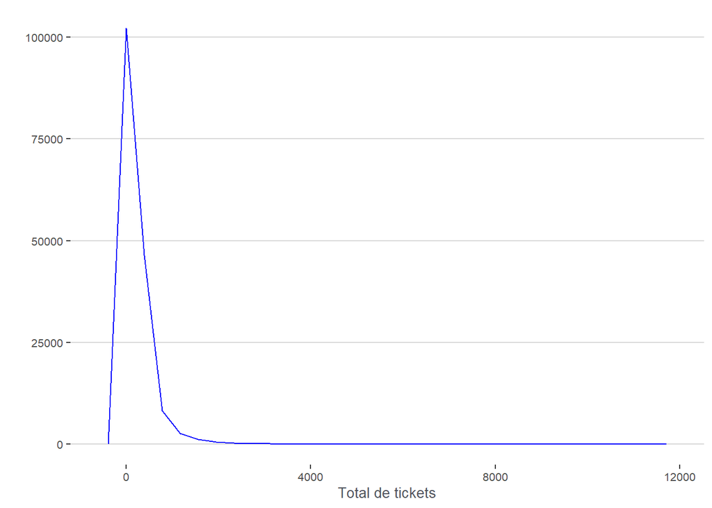

```r
df_sin_negativos <- df %>%
  filter(`TotalTicket$`> 0)


df_sin_negativos %>%
    ggplot(aes(x = `TotalTicket$`)) +
    geom_freqpoly(color = 'blue', stat = "bin", position = "identity", bins=30) +
              xlab("Total de tickets") +
              ylab(" ") +
              theme_hc() +
              theme(legend.position = "top",
              text=element_text(size=10,
                                colour = "#50535C"))
```

Se visualiza la distribución de los tickets, según el canal de compra.

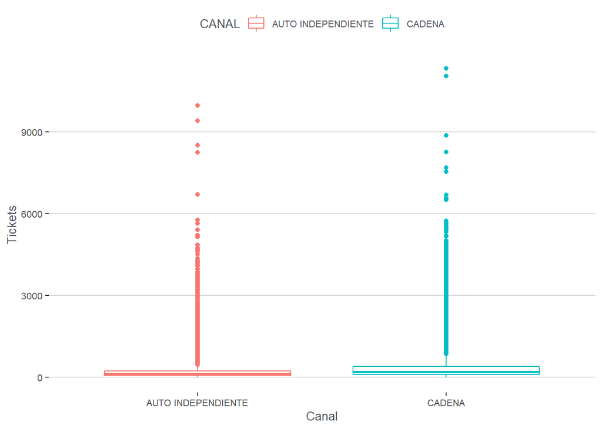

```r
df_sin_negativos %>%
  ggplot(aes(x = CANAL,
               y = `TotalTicket$`,
               color = CANAL)) +
  geom_boxplot() +
  xlab("Canal") +
              ylab("Tickets ") +
              theme_hc() +
              theme(legend.position = "top",
              text=element_text(size=10,
                                colour = "#50535C"))
```

Realizo el gráfico quitando los outliers:

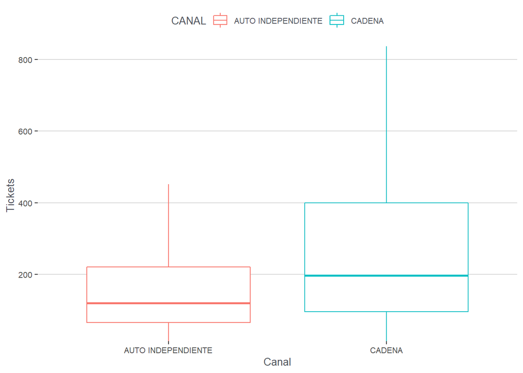

```r
df_sin_negativos %>%
  ggplot(aes(x = CANAL,
               y = `TotalTicket$`,
               color = CANAL)) +
  geom_boxplot(outlier.shape = NA) +
  coord_cartesian(ylim =  c(50, 800)) +
  xlab("Canal") +
              ylab("Tickets ") +
              theme_hc() +
              theme(legend.position = "top",
              text=element_text(size=10,
                                colour = "#50535C"))
```

#### Cantidad de unidades

Se grafica la distribución de cantidad de unidades, según el canal de compra:

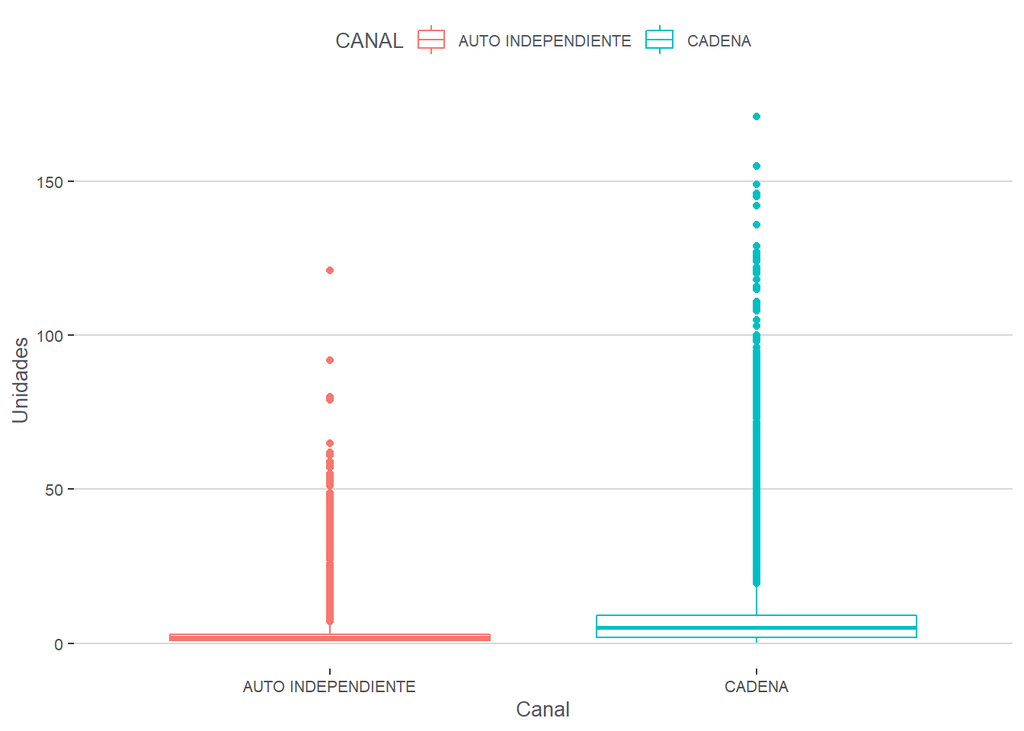

```r
df_sin_negativos_cu <-  df %>%
  filter(CantidadUnidades> 0)

df_sin_negativos_cu %>%
  ggplot(aes(x = CANAL,
               y = CantidadUnidades,
               color = CANAL)) +
  geom_boxplot() +
  xlab("Canal") +
              ylab("Unidades") +
              theme_hc() +
              theme(legend.position = "top",
              text=element_text(size=10,
                                colour = "#50535C"))
```

Observando que existe una cantidad notoria de outliers, se realiza el gráfico sin estos valores:

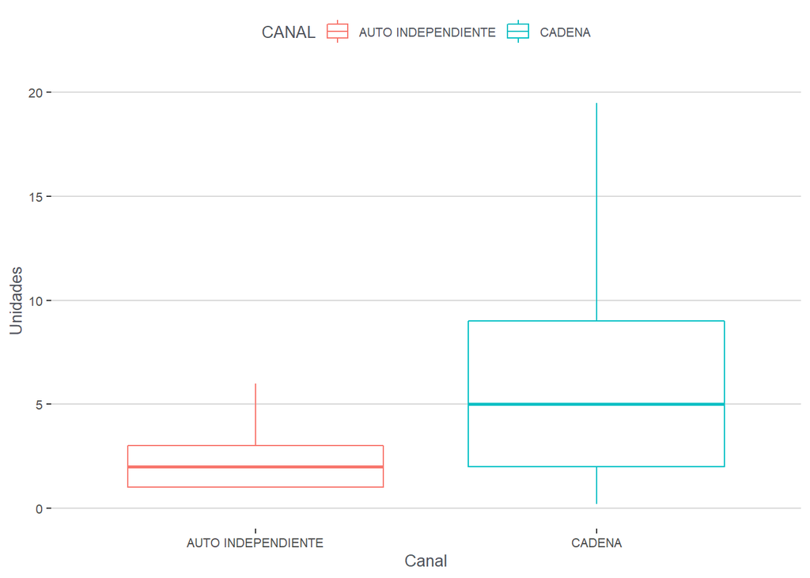

```r
df_sin_negativos_cu %>%
  ggplot(aes(x = CANAL,
               y = CantidadUnidades,
               color = CANAL)) +
  geom_boxplot(outlier.shape = NA) +
  coord_cartesian(ylim =  c(0, 20)) +
  xlab("Canal") +
              ylab("Unidades") +
              theme_hc() +
              theme(legend.position = "top",
              text=element_text(size=10,
                                colour = "#50535C"))
```

Se realiza un gráfico de distribución de los tickets, según el día de compra y el canal:

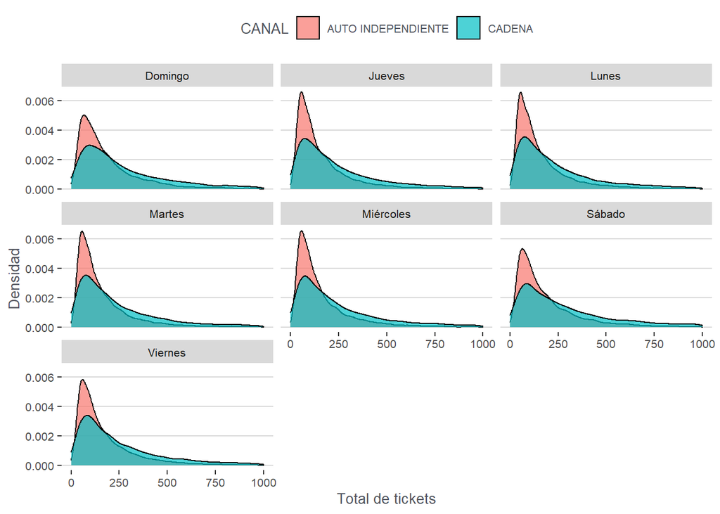

```r
df_reducido <- df %>% filter(`TotalTicket$` > 0 & `TotalTicket$` < 1000)

ggplot(df_reducido, aes(x = `TotalTicket$`, fill = CANAL)) +
  geom_density(alpha = 0.7) +
  facet_wrap(~DiaSemana) +
  xlab("Total de tickets") +
              ylab("Densidad") +
              theme_hc() +
              theme(legend.position = "top",
              text=element_text(size=10,
                                colour = "#50535C"))
```

#### Precio mínimo

Se realiza un gráfico de distribución del precio mínimo, según el día de compra y el canal:

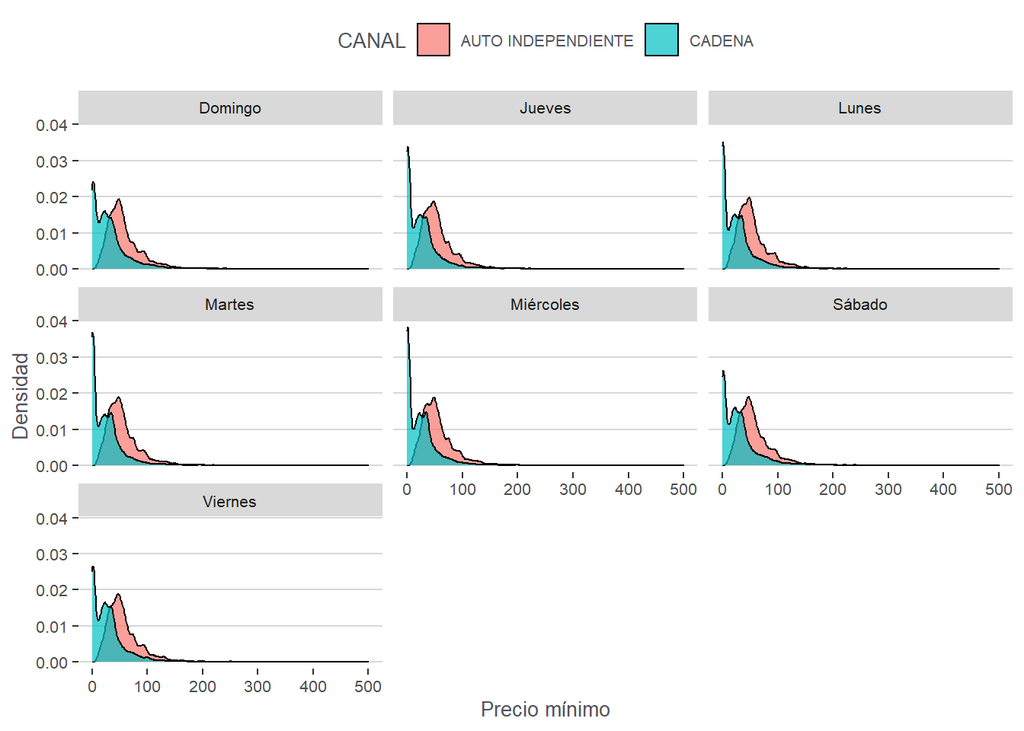

```r
df_reducido_bis <- df %>% filter(PrecioMinimo <= 500)

ggplot(df_reducido_bis, aes(x = PrecioMinimo, fill = CANAL)) +
  geom_density(alpha = 0.7) +
  facet_wrap(~DiaSemana) +
  xlab("Precio mínimo") +
              ylab("Densidad") +
              theme_hc() +
              theme(legend.position = "top",
              text=element_text(size=10,
                                colour = "#50535C"))
```

Se grafica un boxplot del precio mínimo:

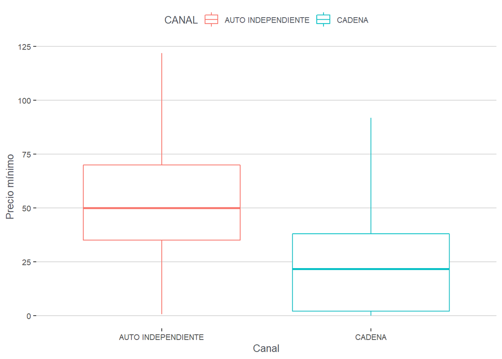

```r
df %>%
  ggplot(aes(x = CANAL,
               y = PrecioMinimo,
               color = CANAL)) +
  geom_boxplot(outlier.shape = NA) +
  coord_cartesian(ylim =  c(0, 120)) +
  xlab("Canal") +
              ylab("Precio mínimo") +
              theme_hc() +
              theme(legend.position = "top",
              text=element_text(size=10,
                                colour = "#50535C"))
```

### Análisis de Silhouette

Se realiza un análisis de silueta para indagar cuan bien cohesionados están los grupos entre sí.

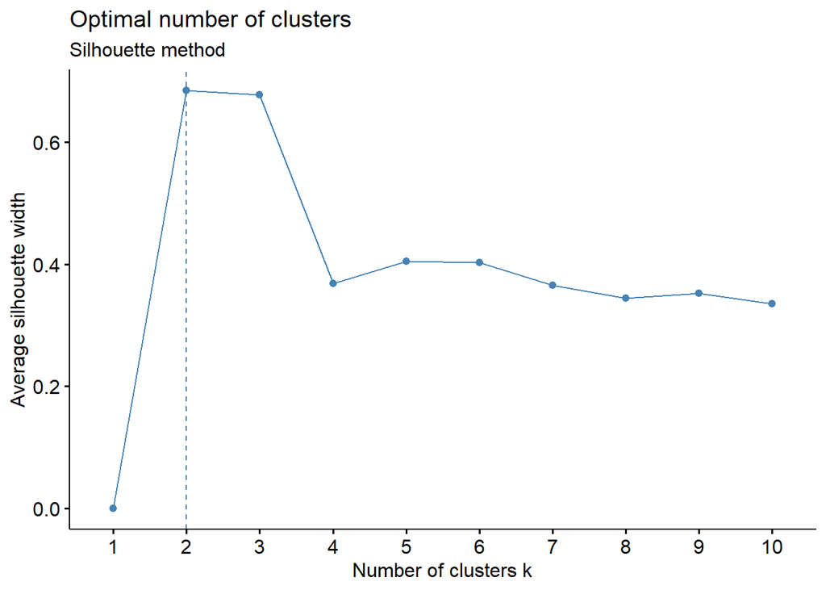

```r
#Se excluye la variable número de ticket
df_sin_nt <- df %>% select(-2)

#Se filtran los valores en función del total de tickets y la cantidad de unidades (sin negativos)
df_sin_nt <- df_sin_nt %>% filter(`TotalTicket$`> 0 & CantidadUnidades > 0)

#obtengo muestra
df_test <- sample_n(df_sin_nt, 10000)


#Se seleccionan variables numéricas para poder aplicar el método de kmeans
df_test_v <- df_test %>% select(3:17)
df_test_v <- df_test_v %>% select(1:7)

#Veo el número óptivo de clusters (obtengo muestra)
df_test_i <- scale(df_test_v)
set.seed(123)
fviz_nbclust(df_test_i, kmeans, method = "silhouette")+
  labs(subtitle = "Silhouette method")
```

### Cluster por k-means

Se obtiene la media de cada cluster y el tamaño de cada uno

```r
km.res <- kmeans(df_test_i, 5, nstart = 30)
km.res
```

```
## K-means clustering with 5 clusters of sizes 1808, 173, 6570, 86, 1363
##
## Cluster means:
##   TotalTicket$ PrecioMaximo PrecioMinimo Cantidad_PRODUCTOS_DIFERENTES
## 1  -0.03804741    0.5630346    0.9261129                    -0.3720401
## 2   5.19280661    2.3382425   -0.6177254                     4.9498001
## 3  -0.34565629   -0.4009133   -0.2066610                    -0.2904016
## 4   1.03638094    4.6237496    6.5668013                    -0.4662102
## 5   0.99212566    0.5971207   -0.5682522                     1.2944724
##   CantidadUnidades Categorias PrecioPromedio
## 1       -0.3337520 -0.3865839     0.96740983
## 2        5.1057996  4.7596861     0.28262948
## 3       -0.2805166 -0.2923160    -0.34435950
## 4        0.2875193 -0.4997892     6.83771336
## 5        1.1286775  1.3492413    -0.09066274
```

[output cut: 289 more lines]

Se grafica la distribución de los clusters:

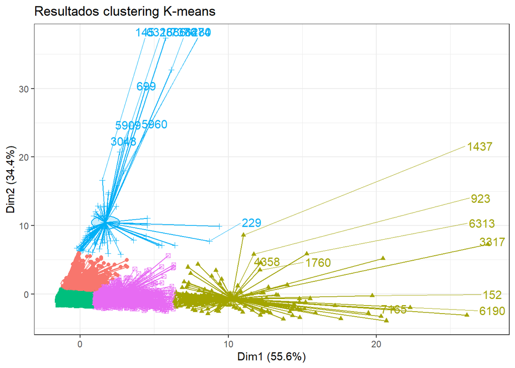

```r
fviz_cluster(object = km.res, data = df_test_i, show.clust.cent = TRUE,
             ellipse.type = "euclid", star.plot = TRUE, repel = TRUE) +
  labs(title = "Resultados clustering K-means") +
  theme_bw() +
  theme(legend.position = "none")
```

Junto los datos del canal de compra y el día de la semana para indagar cómo quedaron los grupos:

```r
dias_canal <- df_test %>% select(1,2)
datos <- df_test_v %>% mutate(cluster = km.res$cluster)
datos <- cbind(datos, dias_canal)
datos <- datos %>% mutate(cluster = as.factor(cluster))

tabla_10 <- head(datos)
kable_styling(kable(tabla_10))
```

| TotalTicket$ | PrecioMaximo | PrecioMinimo | Cantidad_PRODUCTOS_DIFERENTES | CantidadUnidades | Categorias | PrecioPromedio | cluster | CANAL | DiaSemana |
| --- | --- | --- | --- | --- | --- | --- | --- | --- | --- |
| 95.00 | 95.00 | 95 | 1 | 1 | 1 | 95.0000 | 1 | AUTO INDEPENDIENTE | Sábado |
| 94.99 | 69.99 | 25 | 2 | 2 | 2 | 47.4950 | 3 | AUTO INDEPENDIENTE | Jueves |
| 28.00 | 28.00 | 28 | 1 | 1 | 1 | 28.0000 | 3 | AUTO INDEPENDIENTE | Jueves |
| 324.00 | 60.00 | 48 | 2 | 6 | 1 | 57.0000 | 3 | AUTO INDEPENDIENTE | Lunes |
| 168.00 | 100.00 | 28 | 3 | 3 | 3 | 56.0000 | 3 | AUTO INDEPENDIENTE | Viernes |
| 1760.00 | 185.00 | 55 | 11 | 17 | 9 | 102.0833 | 5 | AUTO INDEPENDIENTE | Jueves |

Finalmente, se analizan graficamente los clusters en función de las variables de interés:

```r
resumen <- datos %>% group_by(CANAL, cluster) %>% summarise(total = n())
```

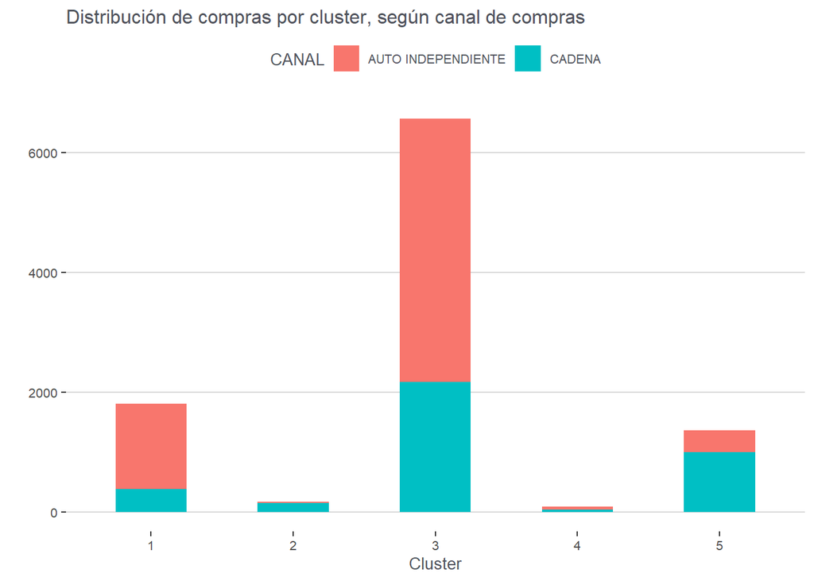

```r
ggplot(data=resumen,
       aes(x=cluster, y=total, fill = CANAL)) +
        geom_bar(stat="identity", width = 0.5) +
        ggtitle ("Distribución de compras por cluster, según canal de compras")+
              xlab("Cluster") +
              ylab("") +
              theme_hc() +
              theme(legend.position = "top",
              text=element_text(size=10,
                                colour = "#50535C"))
```

```r
resumen_dos <- datos %>% group_by(DiaSemana, cluster) %>% summarise(total = n())
```

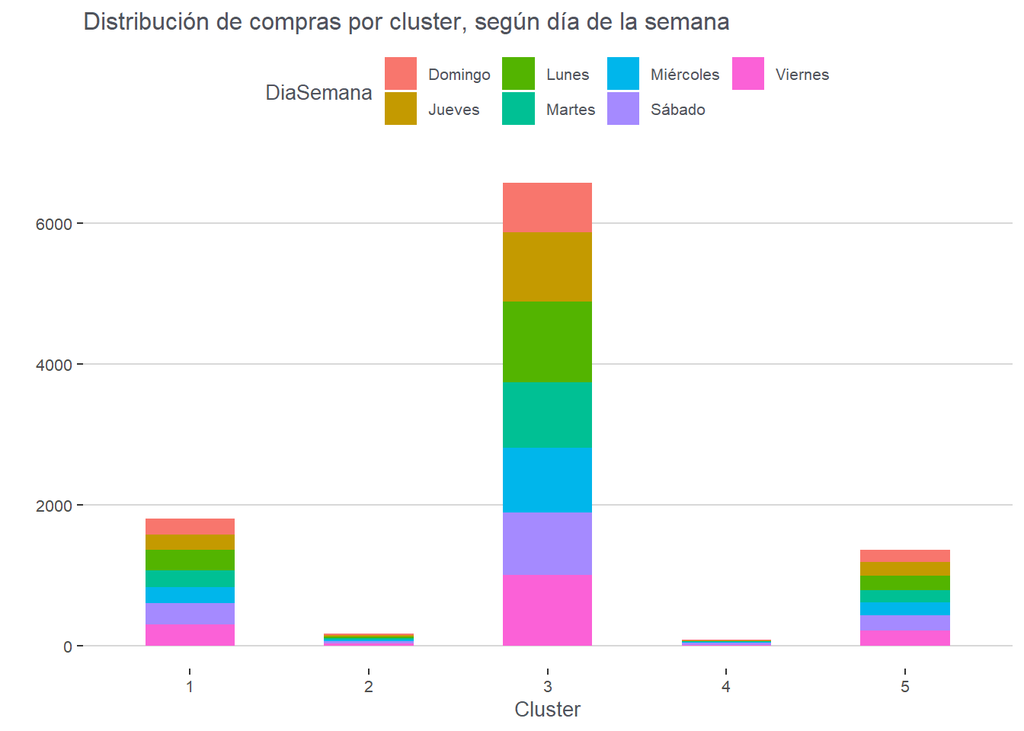

```r
ggplot(data=resumen_dos,
       aes(x=cluster, y=total, fill = DiaSemana)) +
        geom_bar(stat="identity", width = 0.5) +
        ggtitle ("Distribución de compras por cluster, según día de la semana")+
              xlab("Cluster") +
              ylab("") +
              theme_hc() +
              theme(legend.position = "top",
              text=element_text(size=10,
                                colour = "#50535C"))
```